# Example 2: Dynamic + Model Approach with Real Data

David D. Hofmann, Gabriele Cozzi, John Fieberg

2024-01-30

## Purpose

This example analysis serves to illustrate the application of the *dynamic + model* approach with real data collected on a spotted hyena (*Crocuta crocuta*) called “Apollo”. First, we’ll do some slight pre-processing of the GPS data. Since missingness is really low in this dataset, we’ll artificially increase it to a higher level. We will then apply the *dynamic + model* approach to estimate habitat and movement parameters.

## Disclaimer

In this script, we’ll utilize a set of custom functions that are stored in the `Functions.R` file. They are used to compute step-metrics, generate random-steps, and fit step distributions dynamically. Most of the functions can be replaced by much more generalized functions from the `amt` R-package. However, `amt`’s `random_steps()` function doesn’t cope well with sampling random steps from distributions fit to different step-durations. We’ll therefore use of our custom code. If you’d like to apply it to your own data, inspect the functions closels and verify that they suit your purposes.

## Preamble

Let’s start by preparing our R-Session and loading all necessary packages. We also load the custom functions stored in the `Functions.R` file.

```r
# Set notation standards
options(scipen = 999)

# Clear R's brain
rm(list = ls())

# Load required packages
library(tidyverse)     # For data wrangling
library(sf)            # For plotting spatial features
library(lubridate)     # To handle dates and times
library(raster)        # For spatial data manipulation
library(amt)           # To fit step-length and turning-angle distributions
library(survival)      # To fit conditional logistic regression model
library(ggh4x)         # For nested ggplot facets

# Load custom functions
source("02_R-Scripts/Functions.R")
```

## Pre-Processing

We start by loading the GPS data of a spotted hyena (*Crocuta crocuta*) and some covariate layers.

```r
# Load hyena gps data and covariates
dat <- read_rds("03_Data/Hyena_GPS.rds") %>% subset(DOP < 10)
cov <- stack("03_Data/Hyena_Covariates.tif")
```

The hyena GPS data should have been collected every 2 hours, starting from 16:00 and until 04:00 o’clock each day. There usually is also a fix collected at 10:00 o’clock. Since hyenas are mainly nocturnal, we’re only going to focus on the nightly data and drop the 10:00 o’clock fix. In very rare cases, two fixes fall on the same hour. We’ll drop such “duplicates” to avoid having step-durations that are less than 2 hours.

```r
# Keep only fixes that were collected on the desired hour and drop potential
# duplicates
dat <- dat %>%
  mutate(timestamp = round_date(timestamp, "hour")) %>%
  subset(hour(timestamp) %in% c(16, 18, 20, 22, 0, 2, 4)) %>%
  distinct(id, timestamp, .keep_all = T)

# Assess the regular step-duration of our data
samp <- dat %>%
  computeDurations() %>%
  count(duration)
samp
```

```
## # A tibble: 12 × 2
##    duration       n
##    <drtn>     <int>
##  1    2 hours  6444
##  2    4 hours   403
##  3    6 hours    16
##  4    8 hours     1
##  5   12 hours   816
##  6   14 hours   455
##  7   16 hours    28
##  8   18 hours     2
##  9  156 hours     1
## 10  286 hours     1
## 11 9156 hours     1
## 12   NA hours     1
```

If you take a look at the durations between subsequent fixes, you’ll find that most fixes are taken at 2-hourly intervals, with only few 4- or 6-hourly periods. This means that the data is pretty complete (i.e. there is relatively low missingness). To showcase the applicability of the *dynamic+model* approach we’ll introduce a slightly higher level of missingness by removing a fraction of the collected GPS fixes.

```r
# Incrase missingness a bit
dat_rarified <- dat %>%
  rarifyData(missingness = 0.15) %>%
  mutate(
      step_id     = 1:n()
    , step_number = 1:n()
  )

# Compare number of fixes
cbind(Original = nrow(dat), Rarified = nrow(dat_rarified))
```

```
##      Original Rarified
## [1,]     8169     6943
```

Let’s visualize everything, including the spatial covariate layers.

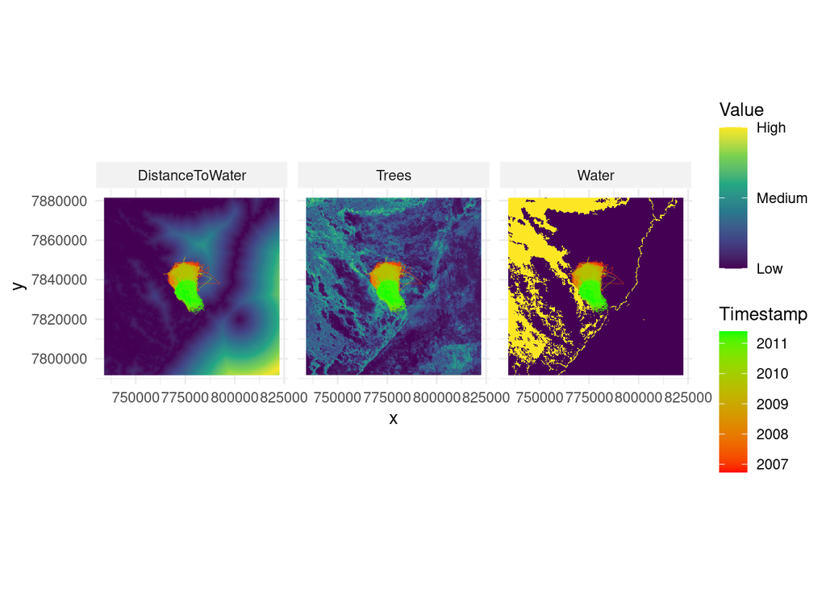

```r
# Visualize covariates and the rarified track (normalization is only for
# visualization purposes)
cov_df <- cov %>%
  as.data.frame(xy = T) %>%
  pivot_longer(Water:Trees, names_to = "Covariate", values_to = "Value") %>%
  group_by(Covariate) %>%
  mutate(Value = (Value - min(Value, na.rm = T)) / (max(Value, na.rm = T) - min(Value, na.rm = T)))
ggplot() +
  geom_raster(data = cov_df, aes(x = x, y = y, fill = Value)) +
  geom_path(data = dat_rarified, aes(x = x, y = y, col = timestamp), linewidth = 0.1) +
  scale_fill_viridis_c(breaks = c(0, 0.5, 1), labels = c("Low", "Medium", "High")) +
  scale_color_datetime(low = "red", high = "green", name = "Timestamp") +
  facet_wrap(~ Covariate) +
  coord_equal() +
  theme_minimal() +
  theme(strip.background = element_rect(fill = "gray95", color = "white"))
```

## Fitting Tentative Distributions

Because we rarified the dataset, the time between consecutive datapoints is not always equal. Let’s ensure the regular step-duration is still 2 hours.

```r
# Assess the regular step-duration of our data
samp <- dat_rarified %>%
  computeDurations() %>%
  count(duration)
samp
```

```
## # A tibble: 15 × 2
##    duration       n
##    <drtn>     <int>
##  1    2 hours  4645
##  2    4 hours   837
##  3    6 hours   130
##  4    8 hours    26
##  5   12 hours   582
##  6   14 hours   500
##  7   16 hours   174
##  8   18 hours    31
##  9   20 hours     8
## 10   22 hours     5
## 11   24 hours     1
## 12  156 hours     1
## 13  286 hours     1
## 14 9158 hours     1
## 15   NA hours     1
```

```r
# Fit step-length and turning angle distributions to different durations
dists <- fitDists(dat_rarified
  , durations = c(2, 4, 6) # Return fitted distributions for durations 1-3
  , regular   = 2          # The regular step-duration is 2
  , dynamic   = T          # Fit distributions dynamically
  , resample  = F          # Don't resample the track
  , rarify    = F          # Don't increase missingness
)

# Show the fitted values
dists
```

```
## $static
## $static$sl
## $static$sl$shape
## [1] 0.734117
##
## $static$sl$scale
## [1] 3309.642
##
##
## $static$ta
## $static$ta$kappa
## [1] 0.1522292
##
## $static$ta$mu
## [1] 0
##
##
##
## $dynamic
## $dynamic$sl
## # A tibble: 3 × 4
##   duration shape scale nsteps_sl
##      <dbl> <dbl> <dbl>     <int>
## 1        2 0.734 3310.      4645
## 2        4 1.07  3727.       837
## 3        6 1.33  3721.       130
##
## $dynamic$ta
## # A tibble: 3 × 4
##   duration  kappa    mu nsteps_ta
##      <dbl>  <dbl> <dbl>     <int>
## 1        2 0.152      0      2907
## 2        4 0.0673     0       670
## 3        6 0.548      0       111
```

You can see that we now have different gamma and von Mises parameters for steps from different durations. We can later use the so fitted distributions to generate random steps matching different step-durations.

## Generating Random Steps

Before generating random steps, we need to split our data into bursts within which the step-duration does not exceed 6.

```r
# Compute bursts within which the step duration does not exceed our forgiveness
dat_rarified_bursted <- computeBursts(dat_rarified, max_duration = 6)
head(dat_rarified_bursted)
```

```
## # A tibble: 6 × 11
##   id           x        y   DOP timestamp           collar step_id step_number
##   <chr>    <dbl>    <dbl> <dbl> <dttm>               <dbl>   <int>       <int>
## 1 Apollo 767968. 7842505.   2.4 2006-09-25 20:00:00   2837       1           1
## 2 Apollo 768672. 7841812.   2   2006-09-25 22:00:00   2837       2           2
## 3 Apollo 768696. 7841775.   6.2 2006-09-26 02:00:00   2837       3           3
## 4 Apollo 768919. 7841383.   1.8 2006-09-26 04:00:00   2837       4           4
## 5 Apollo 768779. 7844103.   3.4 2006-09-26 18:00:00   2837       5           5
## 6 Apollo 769532. 7843941.   4.4 2006-09-26 20:00:00   2837       6           6
## # ℹ 3 more variables: duration <drtn>, irregular <lgl>, burst <dbl>
```

In addition, we need to compute step-metrics (step-lengths and turning-angles) per burst.

```r
# Compute step metrics within bursts
dat_rarified_metrics <- computeMetrics(dat_rarified_bursted)
head(dat_rarified_metrics)
```

```
## # A tibble: 6 × 14
##   burst step_number step_id id         x      y   DOP timestamp           collar
##   <dbl>       <int>   <int> <chr>  <dbl>  <dbl> <dbl> <dttm>               <dbl>
## 1     1           1       1 Apol… 7.68e5 7.84e6   2.4 2006-09-25 20:00:00   2837
## 2     1           2       2 Apol… 7.69e5 7.84e6   2   2006-09-25 22:00:00   2837
## 3     1           3       3 Apol… 7.69e5 7.84e6   6.2 2006-09-26 02:00:00   2837
## 4     1           4       4 Apol… 7.69e5 7.84e6   1.8 2006-09-26 04:00:00   2837
## 5     2           5       5 Apol… 7.69e5 7.84e6   3.4 2006-09-26 18:00:00   2837
## 6     2           6       6 Apol… 7.70e5 7.84e6   4.4 2006-09-26 20:00:00   2837
## # ℹ 5 more variables: duration <drtn>, irregular <lgl>, sl <dbl>, absta <dbl>,
## #   relta <dbl>
```

Finally, we can use the `computeSSF()` function to generate 25 random steps for each valid step (a valid step has a step-length and a turning-angle associated). Note that we cna use the dynamically fitted distributions `dists` to match sampled random steps with the step-durations of observed steps by picking the `dynamic+model` approach. The function `computeSSF()` will also automatically drop any invalid steps or steps with a duration that occurs less than 5 times in the dataset. This is to prevent issues when including the step-duration in the iSSF model.

```r
# Generate random steps
dat_rarified_ssf <- computeSSF(dat_rarified_metrics
  , n_rsteps = 25
  , dists    = dists
  , approach = "dynamic+model"
)
head(dat_rarified_ssf)
```

```
## # A tibble: 6 × 17
##   id     step_number step_id       x        y    x_to     y_to burst   DOP
##   <chr>        <int>   <int>   <dbl>    <dbl>   <dbl>    <dbl> <dbl> <dbl>
## 1 Apollo           2       2 768672. 7841812. 768696. 7841775.     1     2
## 2 Apollo           2       2 768672. 7841812. 766603. 7844105.     1     2
## 3 Apollo           2       2 768672. 7841812. 768591. 7842090.     1     2
## 4 Apollo           2       2 768672. 7841812. 771555. 7843407.     1     2
## 5 Apollo           2       2 768672. 7841812. 770884. 7841092.     1     2
## 6 Apollo           2       2 768672. 7841812. 769424. 7844282.     1     2
## # ℹ 8 more variables: timestamp <dttm>, collar <dbl>, duration <drtn>,
## #   irregular <lgl>, sl <dbl>, absta <dbl>, relta <dbl>, case <dbl>
```

Let’s visualize some of the observed and random steps to ensure everything is working as expected.

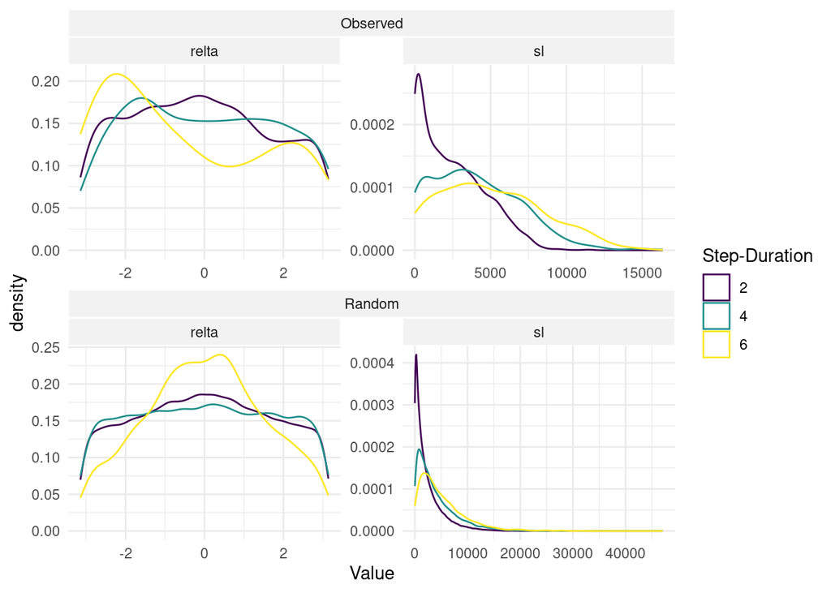

```r
# Verify that steps of different durations follow different sl- and
# ta-distributions
dat_rarified_ssf %>%
  dplyr::select(case, duration, sl, relta) %>%
  pivot_longer(sl:relta, names_to = "Metric", values_to = "Value") %>%
  mutate(Type = ifelse(case == 1, "Observed", "Random")) %>%
  ggplot(aes(x = Value, col = as.factor(duration))) +
    geom_density() +
    facet_nested_wrap(~ Type + Metric, scale = "free") +
    scale_color_viridis_d(name = "Step-Duration") +
    theme_minimal() +
    theme(strip.background = element_rect(fill = "gray95", color = "white"))
```

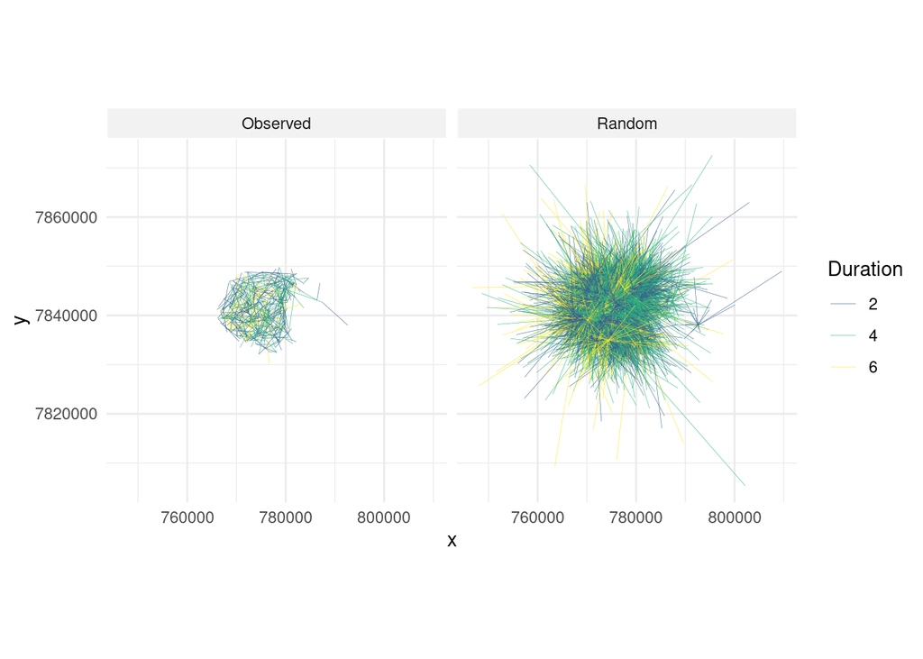

```r
# Visualize some observed and random steps
dat_rarified_ssf %>%
  mutate(Type = ifelse(case == 1, "Observed", "Random")) %>%
  subset(step_number %in% 1:1000) %>%
  ggplot(aes(x = x, y = y, xend = x_to, yend = y_to, col = as.factor(duration))) +
    geom_segment(linewidth = 0.1) +
    scale_color_viridis_d(begin = 0.3, name = "Duration") +
    theme_minimal() +
    coord_equal() +
    facet_wrap(~ Type) +
    theme(strip.background = element_rect(fill = "gray95", color = "white"))
```

## Computing Covariates

We still need to compute all covariates that we want include our iSSF model. This includes spatial covariates at the end-point of each step, as well as step-metrics. We can use the function `computeCovars` for this.

```r
# Compute covariates for all steps (the function will extract spatial covariates
# at the end of each step and also compute log_sl and cos_ta)
dat_rarified_covars <- computeCovars(dat_rarified_ssf
  , covars    = cov
  , extract   = "end"
)
head(dat_rarified_covars)
```

```
##       id step_number step_id        x       y     x_to    y_to burst DOP
## 1 Apollo           2       2 768672.4 7841812 768696.2 7841775     1   2
## 2 Apollo           2       2 768672.4 7841812 766602.8 7844105     1   2
## 3 Apollo           2       2 768672.4 7841812 768591.1 7842090     1   2
## 4 Apollo           2       2 768672.4 7841812 771555.3 7843407     1   2
## 5 Apollo           2       2 768672.4 7841812 770884.1 7841092     1   2
## 6 Apollo           2       2 768672.4 7841812 769424.3 7844282     1   2
##             timestamp collar duration irregular         sl    absta      relta
## 1 2006-09-25 22:00:00   2837  4 hours     FALSE   44.70501 2.579525  0.2323663
## 2 2006-09-25 22:00:00   2837  4 hours     FALSE 3088.23759 5.548751 -3.0815927
## 3 2006-09-25 22:00:00   2837  4 hours     FALSE  289.68375 5.998751 -2.6315927
## 4 2006-09-25 22:00:00   2837  4 hours     FALSE 3294.46790 1.065566 -1.2815927
## 5 2006-09-25 22:00:00   2837  4 hours     FALSE 2325.97862 1.885566 -0.4615927
## 6 2006-09-25 22:00:00   2837  4 hours     FALSE 2581.26187 0.295566 -2.0515927
##   case Water DistanceToWater      Trees   log_sl     cos_ta
## 1    1     0        836.9611 0.05433938 3.800086  0.9731242
## 2    0     0        490.3871 0.03104168 8.035356 -0.9982005
## 3    0     0        953.5060 0.04840513 5.668790 -0.8727445
## 4    0     0       1082.3079 0.04516093 8.100000  0.2851891
## 5    0     0       1560.8099 0.06496403 7.751896  0.8953443
## 6    0     0       2288.0603 0.01759001 7.856034 -0.4624854
```

## Running the Model

We are now ready to estimate parameters using conditional logistic regression. This can be achieved using the `clogit()` function from the `survival` package. Alternatively, one can use the wrapper `fit_clogit()` from the `amt` package. Importantly, we will include interactions among the step-descriptors $sl$, $log(sl)$, and $cos(ta)$ and the step-duration $duration$.

```r
# Ensure the step-duration enters as factor
dat_rarified_covars$duration <- as.factor(dat_rarified_covars$duration)

# Fit the model
mod <- clogit(data = dat_rarified_covars, formula = case ~
  + Water                     # Habitat-selection
  + DistanceToWater           # Habitat-selection
  + Trees                     # Habitat-selection
  + Water:duration            # Habitat x Step-Duration
  + DistanceToWater:duration  # Habitat x Step-Duration
  + Trees:duration            # Habitat x Step-Duration
  + sl                        # Movement Kernel
  + log_sl                    # Movement Kernel
  + cos_ta                    # Movement Kernel
  + sl:duration               # Movement x Step-Duration
  + log_sl:duration           # Movement x Step-Duration
  + cos_ta:duration           # Movement x Step-Duration
  + strata(step_id)
)

# Compute confidence intervals
ci <- confint(mod, level = 0.95)

# Put relevant results together
coefs <- summary(mod)$coefficients
coefs <- data.frame(
    Coefficient = rownames(coefs)
  , Estimate    = coefs[, "coef"]
  , SE          = coefs[, "se(coef)"]
  , Z           = coefs[, "z"]
  , LCI         = ci[, 1]
  , UCI         = ci[, 2]
)

# Show results
coefs
```

```
##                                         Coefficient       Estimate
## Water                                         Water -1.60598834327
## DistanceToWater                     DistanceToWater -0.00004228053
## Trees                                         Trees -0.33695061376
## sl                                               sl  0.00002291308
## log_sl                                       log_sl -0.02411597652
## cos_ta                                       cos_ta -0.05025529802
## Water:duration4                     Water:duration4 -0.32016628939
## Water:duration6                     Water:duration6 -0.67953512295
## DistanceToWater:duration4 DistanceToWater:duration4  0.00001193101
## DistanceToWater:duration6 DistanceToWater:duration6 -0.00001390077
## Trees:duration4                     Trees:duration4  2.74000109719
## Trees:duration6                     Trees:duration6  2.48988828466
## sl:duration4                           sl:duration4 -0.00001282273
## sl:duration6                           sl:duration6 -0.00002974379
## log_sl:duration4                   log_sl:duration4  0.03092037198
## log_sl:duration6                   log_sl:duration6  0.09772409987
## cos_ta:duration4                   cos_ta:duration4 -0.00181537304
## cos_ta:duration6                   cos_ta:duration6 -0.86897331083
##                                       SE          Z             LCI
## Water                     0.165726547269 -9.6905919 -1.930806407201
## DistanceToWater           0.000011747218 -3.5991955 -0.000065304656
## Trees                     0.720566086604 -0.4676193 -1.749234191986
## sl                        0.000008363823  2.7395460  0.000006520286
## log_sl                    0.014523247245 -1.6605086 -0.052581018054
## cos_ta                    0.024291344198 -2.0688562 -0.097865457789
## Water:duration4           0.406296619254 -0.7880112 -1.116493030165
## Water:duration6           1.053526568922 -0.6450100 -2.744409254790
## DistanceToWater:duration4 0.000023670628  0.5040430 -0.000034462565
## DistanceToWater:duration6 0.000050628433 -0.2745646 -0.000113130679
## Trees:duration4           1.686781675358  1.6243958 -0.566030236297
## Trees:duration6           3.725511919242  0.6683345 -4.811980901033
## sl:duration4              0.000018596204 -0.6895347 -0.000049270619
## sl:duration6              0.000041838909 -0.7109123 -0.000111746549
## log_sl:duration4          0.053821048912  0.5745033 -0.074566945500
## log_sl:duration6          0.165204988481  0.5915324 -0.226071727614
## cos_ta:duration4          0.060557849097 -0.0299775 -0.120506576253
## cos_ta:duration6          0.145617308386 -5.9675139 -1.154377990789
##                                      UCI
## Water                     -1.28117027934
## DistanceToWater           -0.00001925641
## Trees                      1.07533296446
## sl                         0.00003930587
## log_sl                     0.00434906502
## cos_ta                    -0.00264513826
## Water:duration4            0.47616045139
## Water:duration6            1.38533900890
## DistanceToWater:duration4  0.00005832459
## DistanceToWater:duration6  0.00008532913
## Trees:duration4            6.04603243067
## Trees:duration6            9.79175747035
## sl:duration4               0.00002362516
## sl:duration6               0.00005225896
## log_sl:duration4           0.13640768945
## log_sl:duration6           0.42151992736
## cos_ta:duration4           0.11687583017
## cos_ta:duration6          -0.58356863086
```